# HW2_MachineLearning

## Aminmohammad Soleymani Abyaneh --------------------------------------------------------- 94100805

## 1. MLE for binomial distribution

In this problem we must find the maximum likelihood estimation for binomial distribution and finde out whether it is biased or unbiased estimation.

### 1. Part A

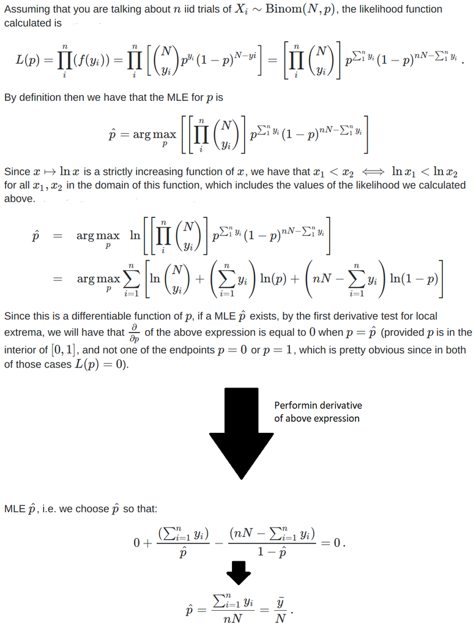

;

### 1. Part B

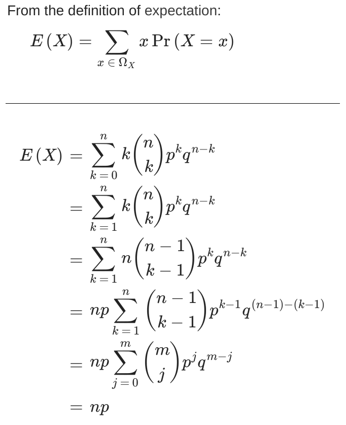

### 1. Part C

The mean square error (MSE) of an estimator $\hat{p}$ of a parameter $p$ is the function of $p$ defined by $E(\hat{p} - p)^2$. This is denoted as $MSE(\hat{p})$. So we have that:

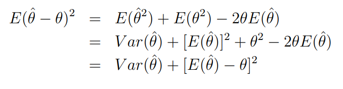

we know that, comforming to previous section, $E(\hat{p}) - p = p - p = 0$. So we have to calculate $Var(\hat{p})$.

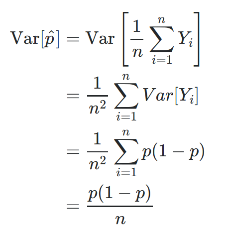

## 2. MLE for multinomial distribution

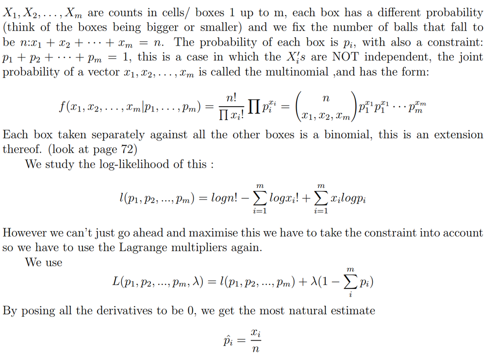

## 3. Overfitting in logistic regression

### 3. Part A

```python
# plotting graphs
import matplotlib.pyplot as plt
# numerical and algebra calculation
import numpy as np
# mathematics like sqrt
import math
# using random numbers
import random
```

To plot a sigmoid function, We need to write a function to return y value for each x input. Create an array named x between -10 to 10 with an interval of 0.2, then pass the array x into sigmoid() which returns an array with corresponding values. And finally plot the result.

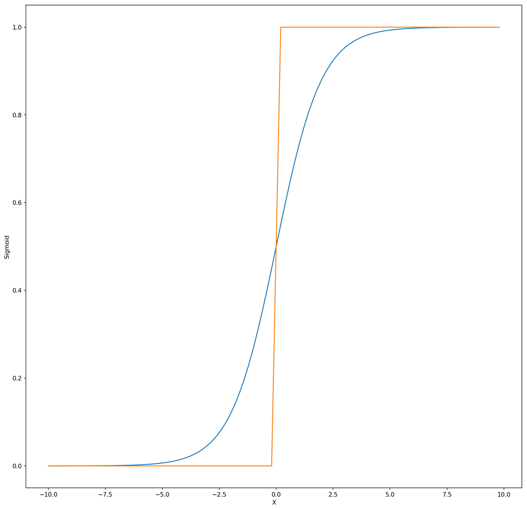

```python
def sigmoid(x):
    return (1 / (1 + np.exp(-x)))

# prepare the data
x = np.array(np.arange(-10., 10., 0.2))
sig_1 = sigmoid(x)
sig_50 = sigmoid(np.multiply(x, 50))

# Overflow accures with 100, result is almost no different from 50.
# sig_100 = sigmoid(np.multiply(x, 100))

# plot the result
plt.figure(figsize=(15, 15), dpi=150)
plt.plot(x,sig_1)
plt.plot(x,sig_50)

# plt.plot(x,sig_100)

plt.ylabel('Sigmoid')
plt.xlabel('X')
plt.show()
```

Due to previous graphs, overfitting accures in large w because the curves is loosing its smoothness and going toward a 0 and 1 splitter which would definitly cause overfitting since small amoints of error would cause massive change in output value from 0 to 1 and vise versa.

### 3. Part B

As it is noted in the question, we have the MAP function as:

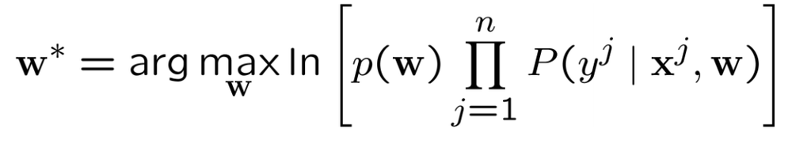

which w is the vector of all weights. Further more we do know that $p(w)$ is in the guassian form as:

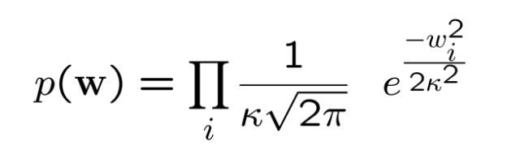

next we are going to write the gradient function for each w element like the following.

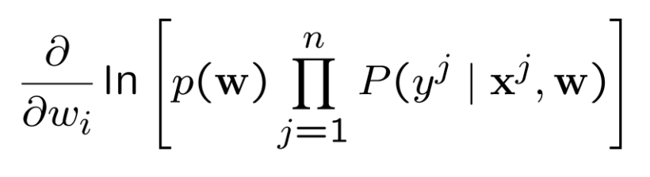

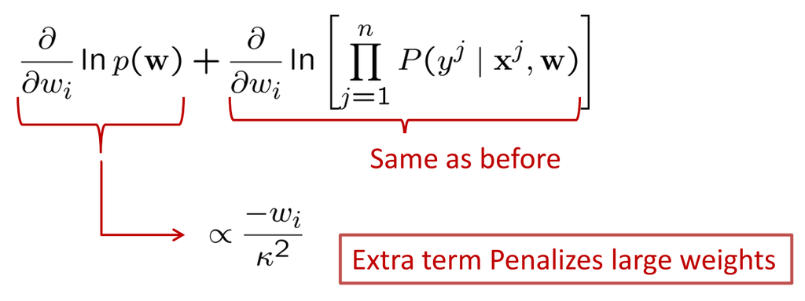

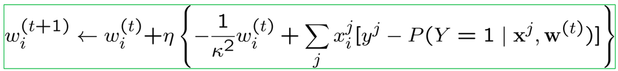

## 4. Implementation of KNN algorithm

Closest neighbor classifiers depend on learning by relationship, that is, by contrasting a given test tuple and preparing tuples that are like it. The preparation tuples are depicted by n traits. Each tuple speaks to a point in a ndimensional space. Thusly, all the preparation tuples are put away in a n-dimensional example space. At the point when given an obscure tuple, a k-closest neighbor classifier looks the example space for the k preparing tuples that are nearest to the obscure tuple. These k preparing tuples are the k "closest neighbors" of the obscure tuple.

In this section first we try to produce data using guassian distribution and numpy. Then we try using KNN with different parameters on the train and test data. In k-NN classification, the output is a class membership. An object is classified by a plurality vote of its neighbors, with the object being assigned to the class most common among its k nearest neighbors (k is a positive integer, typically small). If k = 1, then the object is simply assigned to the class of that single nearest neighbor.

```
Shape of data: (6000, 3)
Shape of label: (6000, 1)
```

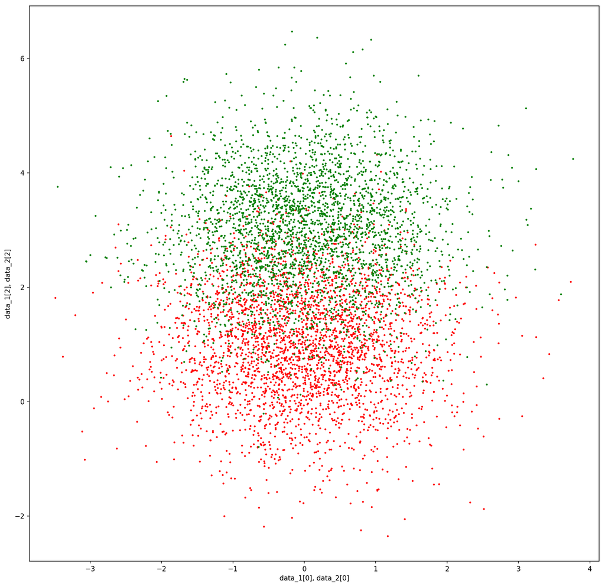

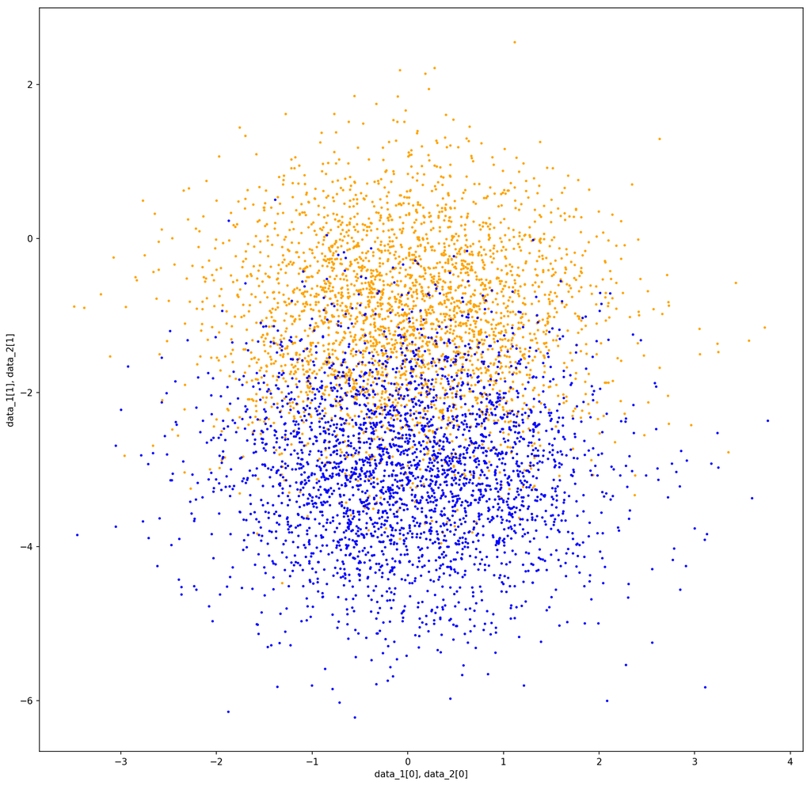

```python
u_1 = np.array([0, -1, 1])
u_2 = np.array([0, -3, 3])

E_1 = [[1, 0, 0],[0, 1, 0], [0, 0, 1]]
E_2 = [[1, 0, 0],[0, 1, 0], [0, 0, 1]]

# generate samples with equal 0.5 probability
data_1 = np.random.multivariate_normal(u_1, E_1, 3000)
data_2 = np.random.multivariate_normal(u_2, E_2, 3000)

# merge the samples
data = np.concatenate([data_1, data_2], axis=0)
label = np.concatenate([np.full((3000, 1), 1), np.full((3000, 1), 2)], axis=0)

print('Shape of data:', data.shape)
print('Shape of label:', label.shape)

# plotting data
plt.figure(figsize=(15, 15), dpi=150)
plt.scatter(data_1[:, 0], data_1[:, 2], color='red', s=3)
plt.scatter(data_2[:, 0], data_2[:, 2], color='green', s=3)
plt.xlabel('data_1[0], data_2[0]')
plt.ylabel('data_1[2], data_2[2]')
plt.show()

plt.figure(figsize=(15, 15), dpi=150)
plt.scatter(data_1[:, 0], data_1[:, 1], color='orange', s=3)
plt.scatter(data_2[:, 0], data_2[:, 1], color='blue', s=3)
plt.xlabel('data_1[0], data_2[0]')
plt.ylabel('data_1[1], data_2[1]')
plt.show()
```

```python
# generate samples with equal 0.5 probability
data_1_t = np.random.multivariate_normal(u_1, E_1, 500)
data_2_t = np.random.multivariate_normal(u_2, E_2, 500)

# merge the samples
data_t = np.concatenate([data_1_t, data_2_t], axis=0)
label_t = np.concatenate([np.full((500, 1), 1), np.full((500, 1), 2)], axis=0)
print('Shape of test data :', data_t.shape)
print('Shape of test label:', data_t.shape)
```

```
Shape of test data : (1000, 3)
Shape of test label: (1000, 3)
```

We need two key functions to complete KNN algorithm. Distance would calculate the distance using sqrt function and numpy. x_1 and x_2 are two inputs and the output is the distance between these two vectors. calling distance function on all train data would categorically give us the KNN. Testing the function using the first subject in data and test is necessary to check the accuracy.

```python
def distance(x1, x2):
    return np.sqrt(((x1-x2)**2).sum())

import sys
print('Train data:', data[0], '\nTest data :', data_t[0])
print('Distance 0 is:', distance(data[0], data_t[0]), file=sys.stderr)
print('Train data:', data[1], '\nTest data :', data_t[1])
print('Distance 1 is:', distance(data[1], data_t[1]), file=sys.stderr)
print('Train data:', data[2], '\nTest data :', data_t[2])
print('Distance 2 is:', distance(data[2], data_t[2]), file=sys.stderr)
print('Train data:', data[3], '\nTest data :', data_t[3])
print('Distance 3 is:', distance(data[3], data_t[3]), file=sys.stderr)
```

```
Train data: [-1.63693168 -1.56155718  0.06369167]
Test data : [-0.51622174 -0.91407214  0.80209319]
Train data: [ 0.43004199 -0.09144113  0.12687258]
Test data : [-0.82810065 -1.52151135 -0.39017391]
Train data: [-0.24929272 -1.15989756  1.8819721 ]
Test data : [ 0.16530031 -2.1328789   0.50972827]
Train data: [-0.48432917 -0.41871523 -0.75341179]
Test data : [ 0.58286439 -1.20750817  0.09087064]
```

```
Distance 0 is: 1.4901222988727805
Distance 1 is: 1.9736668487314393
Distance 2 is: 1.7325222033965115
Distance 3 is: 1.5728665573308644
```

Next function we are going to use is **knn**. This would give us the classification of test data with respect to train data. The sequence of classification is like the following.

```
* Extract the size of train data
* Calculate distance of test vector to each of training vectors
* Sort the aquiered distances
* Perform a frequency count
* Return the most frequent class
```

As it can be seen in the result of printing sorted_labels **most of the nearest naighbors are from class 1**. So the decision will be class 1.

```python
def knn(test, train, label, k, pr=False):
    # finding number of trains
    m = train.shape[0]

    # compute distance from each point and store in dist
    dist = []
    for i in range(m):
        dist.append(distance(test, train[i]))

    dist = np.asarray(dist)
    indx = np.argsort(dist)

    sorted_labels = label[indx][:k]
    if (pr):
        print('Sort labels for k=30 and data_t = data[60]\n', sorted_labels)
    counts = np.unique(sorted_labels, return_counts=True)
    return counts[0][np.argmax(counts[1])]

knn(data_t[60], data, label, 30, pr=True)
```

```
Sort labels for k=30 and data_t = data[60]
 [[1]
 [1]
 [1]
 [1]
 [1]
 [1]
 [1]
 [1]
 [1]
 [1]
 [1]
 [1]
 [1]
 [1]
 [1]
 [1]
 [1]
 [1]
 [1]
 [1]
 [1]
 [1]
 [1]
 [1]
 [1]
 [1]
 [1]
 [1]
 [1]
 [1]]
```

```
1
```

After making sure about correctness of **knn**, we create a loop over entire test cases and gather all the results into an array of prediction. we call this array **predict**.

```python
predict = []
temp = []

kvalues = range(1, 11)
predict.clear()

for k in kvalues:
    temp.clear()
    for t in data_t:
        temp.append(knn(t, data, label, k))
    print('kvalue', k, 'knn calculated')
    predict.append(np.asarray(temp))

import sys
print('Prediction len:', predict.__len__(), file=sys.stderr)
print('KNN actual len:', predict[0].__len__(), file=sys.stderr)
```

```
kvalue 1 knn calculated
kvalue 2 knn calculated
kvalue 3 knn calculated
kvalue 4 knn calculated
kvalue 5 knn calculated
kvalue 6 knn calculated
kvalue 7 knn calculated
kvalue 8 knn calculated
kvalue 9 knn calculated
kvalue 10 knn calculated
```

```
Prediction len: 10
KNN actual len: 1000
```

Calculation of error for each of the k values from 1 to 10 is performed in next section.

```
Error for k = 1  is 0.109
Error for k = 2  is 0.123
Error for k = 3  is 0.096
Error for k = 4  is 0.106
Error for k = 5  is 0.091
Error for k = 6  is 0.097
Error for k = 7  is 0.095
Error for k = 8  is 0.093
Error for k = 9  is 0.085
Error for k = 10  is 0.086
```

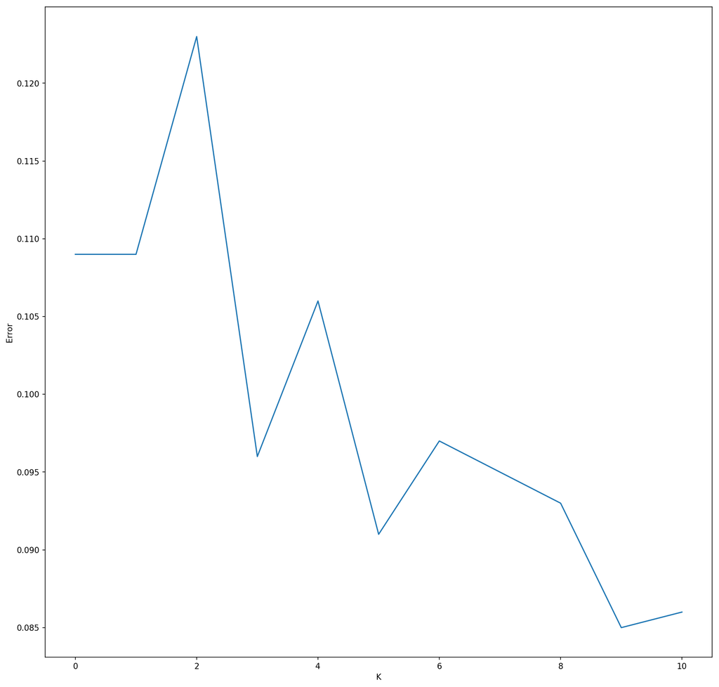

```python
# error function to calculate erro based on indicator
def error(predict, results, k):
    s = 0
    for rvalue, pvalue in zip(results, predict[k - 1]):
        if (int(rvalue) != int(pvalue)):
            s = s + 1
    return (s / len(results))

# calculate error for all predict knn values
e = np.zeros(11)
for i in range(1, 11):
    e[i] = error(predict, label_t, i)
    print('Error for k =', i,' is', e[i])

plt.figure(figsize=(15, 15), dpi=150)

x = np.array(np.arange(0, 11., 1))
e[0] = e[1]
plt.plot(x, e)

plt.ylabel('Error')
plt.xlabel('K')
plt.show()
```

```python
# temp.clear()
# for t in data_t:
#         temp.append(knn(t, data, label, 50))
# predict.append(np.asarray(temp))
print('kvalue', 47, 'knn calculated')
print('Error for k = 47 is', error(predict, label_t, -3), 'and for k = 10 is', e[10])
```

```
kvalue 47 knn calculated
Error for k = 47 is 0.095 and for k = 10 is 0.086
```

For next question we must use two new functions. First one is **normdistance** instead of simple distsnce. This distance is calculated using **numpy linear algebra tools**, with the function called **norm**. Next one is **normknn** which takes another parameter called **p**. p is responsible for the norm number for example to calculate knn in a 3th norm we just need to pass p=3 to the function.

```python
def normdistance(x1, x2, p):
    delta = x1 - x2
    return np.linalg.norm(delta, p)

def normknn(test, train, label, k, p):
    # finding number of trains
    m = train.shape[0]

    # compute distance from each point and store in dist
    dist = []
    for i in range(m):
        dist.append(normdistance(test, train[i], p))

    dist = np.asarray(dist)
    indx = np.argsort(dist)

    sorted_labels = label[indx][:k]
    counts = np.unique(sorted_labels, return_counts=True)
    return counts[0][np.argmax(counts[1])]
```

Now we need to fill the predict array with knn values that are calculated by the norms of 1 to 10. Therefore we perform two for loops to append temp which is filled with knn values to predict.

```python
predict.clear()
temp.clear()

pvalues = range(1, 11)
for p in pvalues:
    for t in data_t:
        temp.append(normknn(t, data, label, 1, p))
    print('kvalue for p =', p, 'and k = 1 is calculated')
    predict.append(np.asarray(temp))

import sys
print('Prediction len:', predict.__len__(), file=sys.stderr)
print('KNN actual len:', predict[0].__len__(), file=sys.stderr)
```

```
kvalue for p = 1 and k = 1 is calculated
kvalue for p = 2 and k = 1 is calculated
kvalue for p = 3 and k = 1 is calculated
kvalue for p = 4 and k = 1 is calculated
kvalue for p = 5 and k = 1 is calculated
kvalue for p = 6 and k = 1 is calculated
kvalue for p = 7 and k = 1 is calculated
kvalue for p = 8 and k = 1 is calculated
kvalue for p = 9 and k = 1 is calculated
kvalue for p = 10 and k = 1 is calculated
```

```
Prediction len: 10
KNN actual len: 1000
```

As we may see there is not a considerable difference in error for different norms so it doesnt have a remarkable effects.

```python
e = np.zeros(11)
for i in range(1, 11):
    e[i] = error(predict, label_t, i)
    print('Error for k =', i,' is', e[i])
```

```
Error for k = 1  is 0.112
Error for k = 2  is 0.112
Error for k = 3  is 0.112
Error for k = 4  is 0.112
Error for k = 5  is 0.112
Error for k = 6  is 0.112
Error for k = 7  is 0.112
Error for k = 8  is 0.112
Error for k = 9  is 0.112
Error for k = 10  is 0.112
```

```python
for i, j in zip(predict[0], predict[8]):
    if (i != j):
        print(i, j)
```

## 5. Logistic regression implementation

### 5. Part A

In order to chose values for the parameters of logistic regression, we use maximum likelihood estimation (MLE). As such we are going to have two steps: (1) write the log-likelihood function and (2) find the values of θ that maximize the log-likelihood function. The labels that we are predicting are binary, and the output of our logistic regression function is supposed to be the probability that the label is one. This means that we can (and should) interpret each label as a Bernoulli random variable: Y ∼ Ber(p).

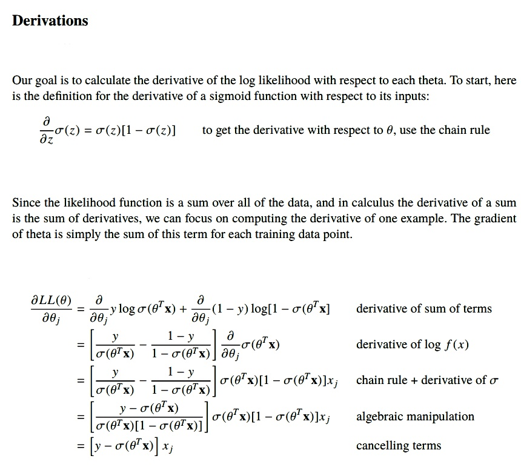

### 5. Part B

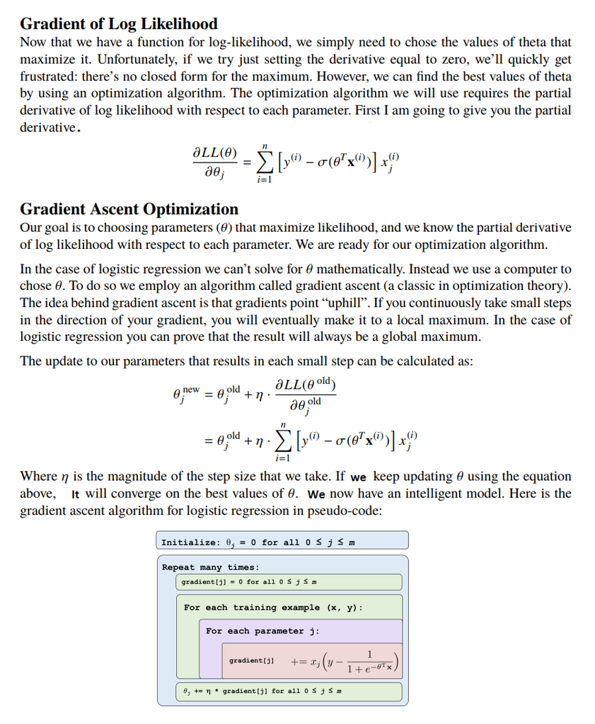

### 5. Part C

First we load the data using pandas. Data is loaded into iris variable. Then we drop the ID column ant take a look at the head and datatypes.

```python
iris = pd.read_csv("Iris.csv") # load the dataset
iris.drop('Id', axis=1, inplace=True) # Drop id column

print(iris.dtypes)
iris.head()
```

```
SepalLengthCm    float64
SepalWidthCm     float64
PetalLengthCm    float64
PetalWidthCm     float64
Species           object
dtype: object
```

|  | SepalLengthCm | SepalWidthCm | PetalLengthCm | PetalWidthCm | Species |
| --- | --- | --- | --- | --- | --- |
| 0 | 5.1 | 3.5 | 1.4 | 0.2 | Iris-setosa |
| 1 | 4.9 | 3.0 | 1.4 | 0.2 | Iris-setosa |
| 2 | 4.7 | 3.2 | 1.3 | 0.2 | Iris-setosa |
| 3 | 4.6 | 3.1 | 1.5 | 0.2 | Iris-setosa |
| 4 | 5.0 | 3.6 | 1.4 | 0.2 | Iris-setosa |

As the problem demands, we need to drop the **Iris-versicolor** column and features related to that color. Next we must map class numbers to each target of iris dataset. Mapping is done assuming **Iris-setosa : 1** and **Iris-virginica : 0**.

```python
iris = iris[iris.Species != 'Iris-versicolor']
iris.tail()
```

|  | SepalLengthCm | SepalWidthCm | PetalLengthCm | PetalWidthCm | Species |
| --- | --- | --- | --- | --- | --- |
| 145 | 6.7 | 3.0 | 5.2 | 2.3 | Iris-virginica |
| 146 | 6.3 | 2.5 | 5.0 | 1.9 | Iris-virginica |
| 147 | 6.5 | 3.0 | 5.2 | 2.0 | Iris-virginica |
| 148 | 6.2 | 3.4 | 5.4 | 2.3 | Iris-virginica |
| 149 | 5.9 | 3.0 | 5.1 | 1.8 | Iris-virginica |

```python
iris['Species'] = iris['Species'].map({'Iris-setosa': 1, 'Iris-virginica': 0})
iris = iris.rename(index=str, columns={'Species' : 'Class'})
iris.head()
```

|  | SepalLengthCm | SepalWidthCm | PetalLengthCm | PetalWidthCm | Class |
| --- | --- | --- | --- | --- | --- |
| 0 | 5.1 | 3.5 | 1.4 | 0.2 | 1 |
| 1 | 4.9 | 3.0 | 1.4 | 0.2 | 1 |
| 2 | 4.7 | 3.2 | 1.3 | 0.2 | 1 |
| 3 | 4.6 | 3.1 | 1.5 | 0.2 | 1 |
| 4 | 5.0 | 3.6 | 1.4 | 0.2 | 1 |

According to the head info above we need to keep **SepalLengthCm, SepalWidthCm, PetalLengthCm, PetalWidthCm** columns of data as our **features** and **Class** as our **target**. We then reshape our labels using the **ravel()** function to attain a rank 1 column vector. This will be required in order for python’s broadcasting to compute the correct values once we start calculating our linear algebra. We then pick four features from both train/test set which we will use to classify our labels and seperate the results of test and train using **train_test_split** function in model_selection of sklearn.

```
Shape of train data: (80, 4) (80,)
```

```
Number of tests is 20 Number of trains is 80
```

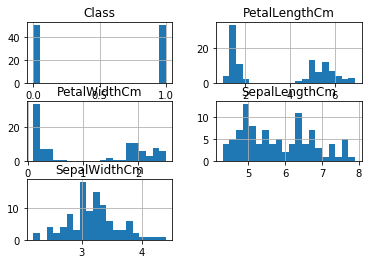

```python
from sklearn.model_selection import train_test_split

iris.hist(bins=20)
X_iris = iris.values[:, [0, 1, 2, 3]]
y_iris = iris.values[:, [4]]
X_iris_train, X_iris_test, y_iris_train, y_iris_test = train_test_split(X_iris, y_iris.ravel(), test_size=0.2, random_state=42)

print('Shape of train data:', X_iris_train.shape, y_iris_train.shape)
print('Number of tests is', len(X_iris_test), 'Number of trains is', len(X_iris_train), file=sys.stderr)
```

We then create a class named **MLLogisticRegression** which contains all the required functions to calculate the logistic regression model and predict the results. Generalized linear models usually tranform a linear model of the predictors by using a link function. In logistic regression, the link function is the sigmoid. We can implement this really easily as it is done in **sigmoid** function. MLLogisticRegression has two main vaiables called **lr : learning rate** and **num_iteration : number of iterations** which has two default values of 0.01 and 100000. The **log-likelihood** can be viewed as a sum over all the training data. The log-likelihood function is typically used to derive the maximum likelihood estimator of the parameter . The estimator is obtained by solving that is, by finding the parameter that maximizes the log-likelihood of the observed sample .

```python
class MLLogisticRegression:
    # class initiaion with learning rate and number of iterations
    def __init__(self, lr=0.01, num_iter=100000):
        self.lr = lr
        self.num_iter = num_iter

    # adding interception to gain more accuracy
    def add_intercept(self, X):
        intercept = np.ones((X.shape[0], 1))
        return np.concatenate((intercept, X), axis=1)

    # defining sigmoid function
    def sigmoid(self, expval):
        return 1 / (1 + np.exp(-expval))

    # defining loss function
    def loglikelihood(self, z, y):
        return np.sum(y * z - np.log(1 + np.exp(z)))

    # fit the model to the training data
    def fit(self, X, y):
        # add interception
        X = self.add_intercept(X)

        # weights initialization
        self.theta = np.zeros(X.shape[1])

        for i in range(self.num_iter):
            z = np.dot(X, self.theta)
            h = self.sigmoid(z)
            gradient = np.dot(X.T, (y - h)) / y.size
            self.theta += self.lr * gradient

            if(i % 10000 == 0):
                z = np.dot(X, self.theta)
                h = self.sigmoid(z)
                print(f'likelihood: {self.loglikelihood(z, y)} \t')

    def predict_prob(self, X):
        X = self.add_intercept(X)
        return self.sigmoid(np.dot(X, self.theta))

    # prediction
    def predict(self, X, threshold = 0.5):
        return (self.predict_prob(X) >= threshold)
```

MLLogisticRegression class with lr=5e-5 and num_iter= 300000 is created and we feed the training set into the model. Performing prediction on test data and comparing it to real test target results we measure the accuracy. Then a sklearn Logistic regression model is created and the results are compared which yeilds accuracy=1 for both cases. Values of likelihood function are printed in each 10000 steps.

```python
trainmodel = MLLogisticRegression(lr=5e-5, num_iter=300000)
trainmodel.fit(X_iris_train, y_iris_train)
preds = trainmodel.predict(X_iris_test)

from sklearn.metrics import accuracy_score
print('\nAccuracy of designed logistic regression model is', accuracy_score(y_iris_test, preds), file=sys.stderr)
print('Data test:\n', y_iris_test, '\nPrediction:\n', preds)
```

```
likelihood: -55.4446084194882
likelihood: -32.9425751177603
likelihood: -22.880372685623495
likelihood: -17.18653876799968
likelihood: -13.636416533502604
likelihood: -11.24841124926888
likelihood: -9.546681506218814
likelihood: -8.278982762654584
likelihood: -7.3011799053510575
likelihood: -6.525689691612115
likelihood: -5.896536888185462
likelihood: -5.3764185327263245
likelihood: -4.939587577329028
likelihood: -4.567736356580061
likelihood: -4.247510802449099
likelihood: -3.968952749409164
likelihood: -3.724491885517751
likelihood: -3.5082747494607904
likelihood: -3.315706834142644
likelihood: -3.1431331387689307
likelihood: -2.9876108682837796
likelihood: -2.8467448075384256
likelihood: -2.7185661650730975
likelihood: -2.6014421043215057
likelihood: -2.494007289923583
likelihood: -2.3951114613378004
likelihood: -2.303778832701035
likelihood: -2.219176327796564
likelihood: -2.1405884913786934
likelihood: -2.067397499211388
Data test:
 [0. 0. 0. 1. 1. 1. 1. 0. 1. 1. 1. 1. 0. 1. 0. 1. 0. 0. 1. 1.]
Prediction:
 [False False False  True  True  True  True False  True  True  True  True
 False  True False  True False False  True  True]
```

```
Accuracy of designed logistic regression model is 1.0
```

```python
from sklearn.linear_model import LogisticRegression

clf = LogisticRegression(solver='lbfgs', fit_intercept=True, C = 1e15)
clf.fit(X_iris_train, y_iris_train)
clf.predict(X_iris_test)
print('LogisticRegression of Scikitlearn', clf.score(X_iris_train, y_iris_train), file=sys.stderr)
```

```
LogisticRegression of Scikitlearn 1.0
```

### 5. Part D

```python
trainmodel = MLLogisticRegression(lr=5e-3, num_iter=300000)
trainmodel.fit(X_iris_train, y_iris_train)
preds = trainmodel.predict(X_iris_test)

from sklearn.metrics import accuracy_score
print('Accuracy of designed logistic regression model is', accuracy_score(y_iris_test, preds), file=sys.stderr)
print('Data test:\n', y_iris_test, '\nPrediction:\n', preds)
```

```
likelihood: -54.7529404209332
likelihood: -0.6084273977581887
likelihood: -0.30843854931521697
likelihood: -0.2075892022570532
likelihood: -0.15682365078192984
likelihood: -0.12619536723983313
likelihood: -0.10568060782784074
likelihood: -0.09096753735312892
likelihood: -0.0798930707471391
likelihood: -0.07125188398585544
likelihood: -0.06431880265166443
likelihood: -0.05863119189753789
likelihood: -0.053879911729853056
likelihood: -0.04985047977758755
likelihood: -0.04638938512400044
likelihood: -0.04338383988763107
likelihood: -0.04074910224981373
likelihood: -0.03842026037856097
likelihood: -0.03634674659073676
likelihood: -0.03448857836799501
likelihood: -0.032813723377428876
likelihood: -0.03129621481896079
likelihood: -0.029914779007273046
likelihood: -0.02865181972443617
likelihood: -0.027492655580861964
likelihood: -0.02642493974772508
likelihood: -0.025438213105756936
likelihood: -0.024523556324771986
likelihood: -0.02367331621670915
likelihood: -0.022880888489370692
Data test:
 [0. 0. 0. 1. 1. 1. 1. 0. 1. 1. 1. 1. 0. 1. 0. 1. 0. 0. 1. 1.]
Prediction:
 [False False False  True  True  True  True False  True  True  True  True
 False  True False  True False False  True  True]
```

```
Accuracy of designed logistic regression model is 1.0
```

```python
trainmodel = MLLogisticRegression(lr=5e-1, num_iter=300000)
trainmodel.fit(X_iris_train, y_iris_train)
preds = trainmodel.predict(X_iris_test)

from sklearn.metrics import accuracy_score
print('Accuracy of designed logistic regression model is', accuracy_score(y_iris_test, preds), file=sys.stderr)
print('Data test:\n', y_iris_test, '\nPrediction:\n', preds)
```

```
likelihood: -88.69029464934175
likelihood: -0.006878497470181735
likelihood: -0.003513498059195268
likelihood: -0.0023710075615005696
likelihood: -0.0017934322460829402
likelihood: -0.0014441245635475508
likelihood: -0.0012098007895711745
likelihood: -0.0010415696540093274
likelihood: -0.0009148484188082852
likelihood: -0.0008159160847478693
likelihood: -0.0007365069468106895
likelihood: -0.000671342459402207
likelihood: -0.0006168925367171375
likelihood: -0.0005707063509526303
likelihood: -0.0005310287965120105
likelihood: -0.0004965697500153362
likelihood: -0.0004663595032581609
likelihood: -0.0004396550080503147
likelihood: -0.0004158772415147801
likelihood: -0.00039456826701494947
likelihood: -0.0003753611215076561
likelihood: -0.00035795826977231
likelihood: -0.0003421159089912197
likelihood: -0.00032763235005245546
likelihood: -0.00031433929087274577
likelihood: -0.00030209517475379905
likelihood: -0.0002907800747522032
likelihood: -0.0002802917097834125
likelihood: -0.00027054231061785406
likelihood: -0.0002614561314079562
Data test:
 [0. 0. 0. 1. 1. 1. 1. 0. 1. 1. 1. 1. 0. 1. 0. 1. 0. 0. 1. 1.]
Prediction:
 [False False False  True  True  True  True False  True  True  True  True
 False  True False  True False False  True  True]
```

```
Accuracy of designed logistic regression model is 1.0
```

```python
trainmodel = MLLogisticRegression(lr=10, num_iter=300000)
trainmodel.fit(X_iris_train, y_iris_train)
preds = trainmodel.predict(X_iris_test)

from sklearn.metrics import accuracy_score
print('Accuracy of designed logistic regression model is', accuracy_score(y_iris_test, preds), file=sys.stderr)
print('Data test:\n', y_iris_test, '\nPrediction:\n', preds)
```

```
likelihood: -1690.8681249999995
likelihood: 0.0
likelihood: 0.0
likelihood: 0.0
likelihood: 0.0
likelihood: 0.0
likelihood: 0.0
likelihood: 0.0
likelihood: 0.0
likelihood: 0.0
likelihood: 0.0
likelihood: 0.0
likelihood: 0.0
likelihood: 0.0
likelihood: 0.0
likelihood: 0.0
likelihood: 0.0
likelihood: 0.0
likelihood: 0.0
likelihood: 0.0
likelihood: 0.0
likelihood: 0.0
likelihood: 0.0
likelihood: 0.0
likelihood: 0.0
likelihood: 0.0
likelihood: 0.0
likelihood: 0.0
likelihood: 0.0
likelihood: 0.0
Data test:
 [0. 0. 0. 1. 1. 1. 1. 0. 1. 1. 1. 1. 0. 1. 0. 1. 0. 0. 1. 1.]
Prediction:
 [False False False  True  True  True  True False  True  True  True  True
 False  True False  True False False  True  True]
```

```
Accuracy of designed logistic regression model is 1.0
```

```python
trainmodel = MLLogisticRegression(lr=1e-8, num_iter=300000)
trainmodel.fit(X_iris_train, y_iris_train)
preds = trainmodel.predict(X_iris_test)

from sklearn.metrics import accuracy_score
print('Accuracy of designed logistic regression model is', accuracy_score(y_iris_test, preds), file=sys.stderr)
print('Data test:\n', y_iris_test, '\nPrediction:\n', preds)
```

```
likelihood: -55.45177301123164
likelihood: -55.437451718162464
likelihood: -55.42315905743675
likelihood: -55.40889494155897
likelihood: -55.394659283292796
likelihood: -55.38045199566048
likelihood: -55.36627299194221
likelihood: -55.35212218567555
likelihood: -55.33799949065477
likelihood: -55.32390482093025
likelihood: -55.30983809080785
likelihood: -55.29579921484832
likelihood: -55.28178810786666
likelihood: -55.267804684931505
likelihood: -55.25384886136453
likelihood: -55.239920552739804
likelihood: -55.22601967488321
likelihood: -55.21214614387179
likelihood: -55.19829987603316
likelihood: -55.1844807879449
likelihood: -55.17068879643389
likelihood: -55.1569238185758
likelihood: -55.14318577169434
likelihood: -55.12947457336077
likelihood: -55.11579014139319
likelihood: -55.102132393856024
likelihood: -55.08850124905932
likelihood: -55.074896625558196
likelihood: -55.06131844215221
likelihood: -55.04776661788475
Data test:
 [0. 0. 0. 1. 1. 1. 1. 0. 1. 1. 1. 1. 0. 1. 0. 1. 0. 0. 1. 1.]
Prediction:
 [False False False False False False False False False False False False
 False False False False False False False False]
```

```
Accuracy of designed logistic regression model is 0.4
```

## 6. Kaggle spam detection

Importing neccessary libraries is the first step. We need to add pandas to manipulate and read csv data.

```python
# linear algebra
import numpy as np
# data processing
import pandas as pd
# output error
import sys
# plotting graphs
import matplotlib.pyplot as plt
# Creating numeric features from text messages
from sklearn.feature_extraction.text import CountVectorizer
# split train and test datasets
from sklearn.model_selection import train_test_split
# knn calculations
from sklearn.neighbors import KNeighborsClassifier
# error calculation
from sklearn import metrics
```

We read the data into data variable and print the head of data. We also print abstract value statistics. It is noticed that we have 4360 none-spam and 1368 spam emails.

```python
data = pd.read_csv("emails.csv", encoding= "latin-1")
data.head()
```

|  | text | spam |
| --- | --- | --- |
| 0 | Subject: naturally irresistible your corporate... | 1 |
| 1 | Subject: the stock trading gunslinger fanny i... | 1 |
| 2 | Subject: unbelievable new homes made easy im ... | 1 |
| 3 | Subject: 4 color printing special request add... | 1 |
| 4 | Subject: do not have money , get software cds ... | 1 |

```python
data.spam.value_counts()
```

```
0    4360
1    1368
Name: spam, dtype: int64
```

Next we should try to split test and train data using scikitlearn **train_test_split** module. This splits arrays or matrices into random train and test subsets and return them into lists we have assigned to in the left hand side.

```python
message_train, message_test, spam_train, spam_test = train_test_split(data["text"], data["spam"], test_size=0.2, random_state=10)
print('X Train Len:', len(message_train))
print('X Test  Len:', len(message_test))
print('-------------------')
print('Total Samples:', len(message_train) + len(message_test))
```

```
X Train Len: 4582
X Test  Len: 1146
-------------------
Total Samples: 5728
```

We check for one of the train datas to make sure about the correctness of above operation.

```python
print(message_train[5])
print('Spam Status:', spam_train[5], file=sys.stderr)
```

```
Subject: great nnews  hello , welcome to medzonline sh groundsel op  we are pleased to introduce ourselves as one of the ieading online phar felicitation maceuticai shops .  helter v  shakedown r  a cosmopolitan l  l blister l  l bestow ag  ac tosher l  is coadjutor va  confidant um  andmanyother . …
```

```
Spam Status: 1
```

The text must be parsed to remove words, called tokenization. Then the words need to be encoded as integers or floating point values for use as input to a machine learning algorithm, called feature extraction (or vectorization). The scikit-learn library offers easy-to-use tools to perform both tokenization and feature extraction of your text data. A simple and effective model for thinking about text documents in machine learning is called the Bag-of-Words Model, or BoW.

The model is simple in that it throws away all of the order information in the words and focuses on the occurrence of words in a document. This can be done by assigning each word a unique number. Then any document we see can be encoded as a fixed-length vector with the length of the vocabulary of known words. The value in each position in the vector could be filled with a count or frequency of each word in the encoded document. This is the bag of words model, where we are only concerned with encoding schemes that represent what words are present or the degree to which they are present in encoded documents without any information about order. There are many ways to extend this simple method, both by better clarifying what a “word” is and in defining what to encode about each word in the vector.

We need to convert text messages to feature vectors. Using **CountVectorizer** is requiered to accomplish the task. CountVectorizer counts all the words and represent the result as vector array or matrix. For stop word parameter, if ‘english’, a built-in stop word list for English is used. Stop words are words like “and”, “the”, “him”, which are presumed to be uninformative in representing the content of a text, and which may be removed to avoid them being construed as signal for prediction. Sometimes, however, similar words are useful for prediction, such as in classifying writing style or personality.

```python
cv = CountVectorizer(stop_words="english")
cv.fit(message_train)
print('Total number of vocabulary elements is', len(cv.vocabulary_))
```

```
Total number of vocabulary elements is 32938
```

The vectors returned from a call to **transform()** will be sparse vectors, and we may transform them back to numpy arrays to look and better understand what is going on by calling the **toarray()** function. The sparse matrix is represented using three one-dimensional arrays for the non-zero values, the extents of the rows, and the column indexes. Compressed Sparse Column. The same as the Compressed Sparse Row method except the column indices are compressed and read first before the row indices. When a sparse matrix is represented with 2-dimensional array, we waste lot of space to represent that matrix. For example, consider a matrix of size 100 X 100 containing only 10 non-zero elements.

```python
message_train_df = cv.transform(message_train)
message_test_df = cv.transform(message_test)
print(type(message_test_df))
print('Train shape is:', message_train_df.shape, 'Test shape is:', message_test_df.shape)
print(message_train_df.toarray(), file=sys.stderr)
```

```
Train shape is: (4582, 32938) Test shape is: (1146, 32938)
```

```
[[0 0 0 ... 0 0 0]
 [0 0 0 ... 0 0 0]
 [4 0 0 ... 0 0 0]
 ...
 [0 0 0 ... 0 0 0]
 [3 0 0 ... 0 0 0]
 [0 0 0 ... 0 0 0]]
```

We can then see that the encoded vector is a sparse matrix. Finally, we can see an array version of the encoded vector showing a count of occurrence for each word except the stop words. To measure the distance between points A and B in a feature space, various distance functions have been used in the literature, in which the Euclidean distance function is the most widely used one and default of sklearn lilbrary.

Finally, we try to use a knn model with default metric which is Euclidean. also a list of all available metrics is available below.

```python
from sklearn.neighbors import VALID_METRICS
VALID_METRICS['brute']
```

```
['cityblock',
 'cosine',
 'euclidean',
 'l2',
 'l1',
 'manhattan',
 'precomputed',
 'braycurtis',
 'canberra',
 'chebyshev',
 'correlation',
 'cosine',
 'dice',
 'hamming',
 'jaccard',
 'kulsinski',
 'mahalanobis',
 'matching',
 'minkowski',
 'rogerstanimoto',
 'russellrao',
 'seuclidean',
 'sokalmichener',
 'sokalsneath',
 'sqeuclidean',
 'yule',
 'wminkowski']
```

**knn_evaluation** function, as it is obvious from its name, is used to evaluate each knn model. It performs the following steps:

```
* create a range called kvalues
* create a list called e and make sure about its values
* perform a for loop on all kvalues to fined the score for each model and append it to e
* find the maximum of e
* plot the figure showing score results
```

```python
# function gets input and evaluates knn model
def knn_evaluation(message_train_df, message_test_df, spam_train, spam_test, m):
    kvalues = range(1, 30)

    e = []
    e.clear()

    for k in kvalues:
        knn = KNeighborsClassifier(n_neighbors=k, metric=m)
        knn.fit(message_train_df, spam_train)
        spam_predict = knn.predict(message_test_df)
        e.append(metrics.accuracy_score(spam_test, spam_predict))

    m = max(e)
    print('Maximum score in knn is:', m, 'For K =', [i + 1 for i, j in enumerate(e) if j == m], file=sys.stderr)

    error = np.asarray(e)
    plt.figure(figsize=(15, 15), dpi=150)

    x = np.array(np.arange(1, len(error) + 1, 1))

    plt.plot(x, error)

    # plotting data
    plt.ylabel('Calculated Score using Euclidean Distance')
    plt.xlabel('K value')
    plt.show()
```

```
Maximum score in knn is: 0.9118673647469459 For K = [3]
```

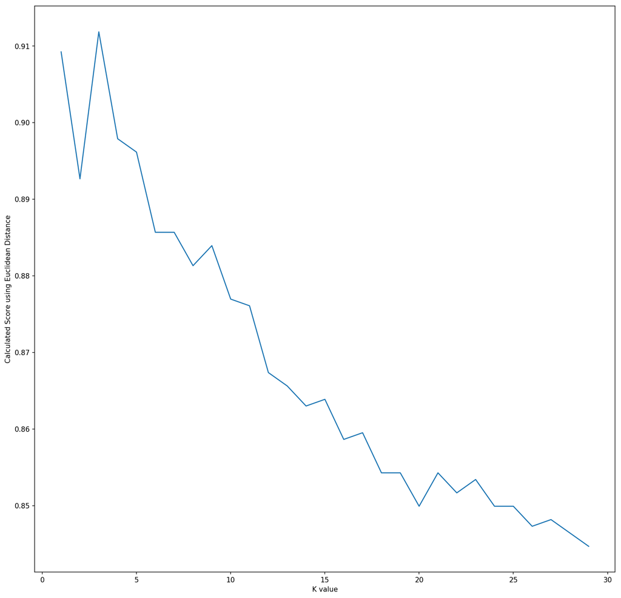

```python
knn_evaluation(message_train_df, message_test_df, spam_train, spam_test, 'euclidean')
```

We have found the best score which is 0.912 in k = 3. As the diagram implies, score values after k = 3 are decreasing so the best score is necessarily related to k = 3.

```
Maximum score in knn is: 0.9860383944153578 For K = [1]
```

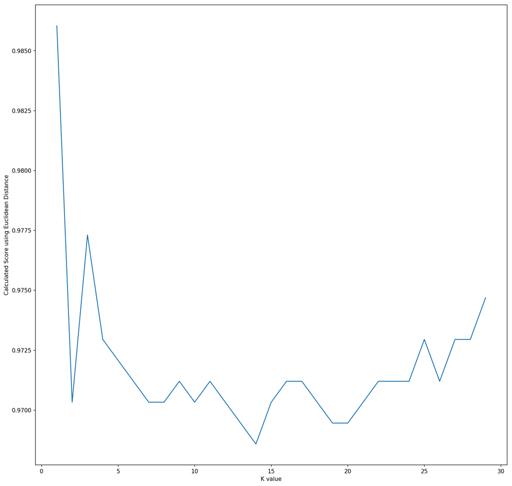

```python
knn_evaluation(message_train_df, message_test_df, spam_train, spam_test, 'cosine')
```

Naive Bayes methods are a set of supervised learning algorithms based on applying Bayes’ theorem with the “naive” assumption of conditional independence between every pair of features given the value of the class variable. Bayes method is more accurate on these sort of problems so i decided to test it as well. The **multinomial Naive Bayes classifier** is suitable for classification with discrete features (e.g., word counts for text classification). The multinomial distribution normally requires integer feature counts. However, in practice, fractional counts such as tf-idf may also work.

```python
from sklearn.naive_bayes import MultinomialNB
from sklearn.metrics import accuracy_score

bmodel = MultinomialNB(alpha=1.8)
bmodel.fit(message_train_df,spam_train)
bpred = bmodel.predict(message_test_df)

print('Accuracy of naive bayes model is:', accuracy_score(spam_test, bpred), file=sys.stderr)
```

```
Accuracy of naive bayes model is: 0.9947643979057592
```